# prelim behavioral analyses - dictator task

Brooke Staveland

11/26/2019

These analyses started for two main reasons: 1) Deborah and I wanted to run some common sense checks to make sure patients were attending to the task, and to identify any one who may not be and 2) we wanted to see how the sets presented in this task correspond to the task in *Andreoni & Miller 2002* and *Saez et al 2015*.

I think I figured out the task structure, but would love it if you could confirm. However, in checking the patient data we realized there was a very strong bias to the left, which I will dig into below. I am worried about how we will be able to interpret at least four of the subject’s data, and we might want to take up Bob’s suggestion that we collect new subjects. Or maybe the left side bias was indeed purposefully built into the task, and I am just missing the rationale?

# Task Structure

In looking through the task code, I was able to see that the order and the sets (ie `Left_self 12`, `Left_other 12`, `Right_self 10`, `Right_other 10`) were all controlled by the csv `payoffs_active3.csv`, and the order and set types was fixed among all subjects (no counterbalancing).

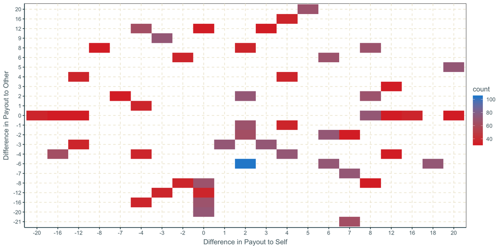

The color represents the number of trials. And from the lack of symmetry whatsoever I figured I have the wrong way of thinking about trials. So I tried looking at ratios instead. I again calculated the difference in payout for the self and for the other, but characterized each trial as a ratio between these numbers. Below, I group all these trial types on the x axis, and on the y the number of such trials. Again, the negative vs positive tells us which side was better, so `20:0`, means the difference for the self between left and right options was 20, there were no differences for the other subject, and that the better option for self payout was on the left.

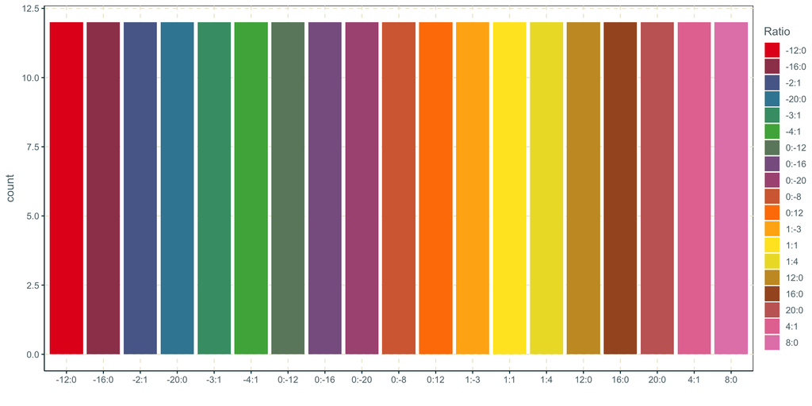

So there are 12 of each trial type, which seems human designed. We can also see that some of these trial types are counterbalanced between left and right, but some are not. This will be shown more clearly below, but there tends to be worse options for the self on the right, and better options on the left.

# Left Bias

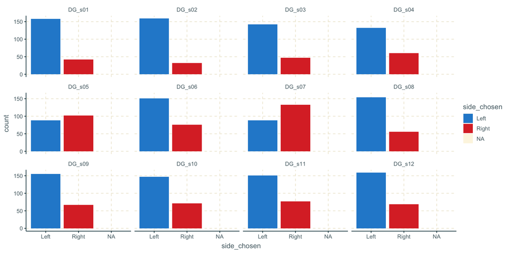

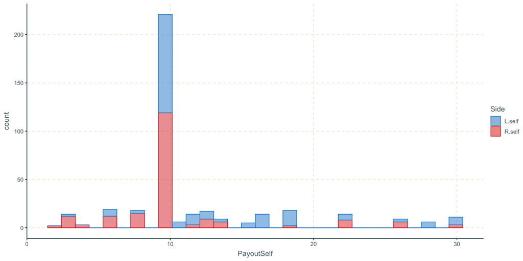

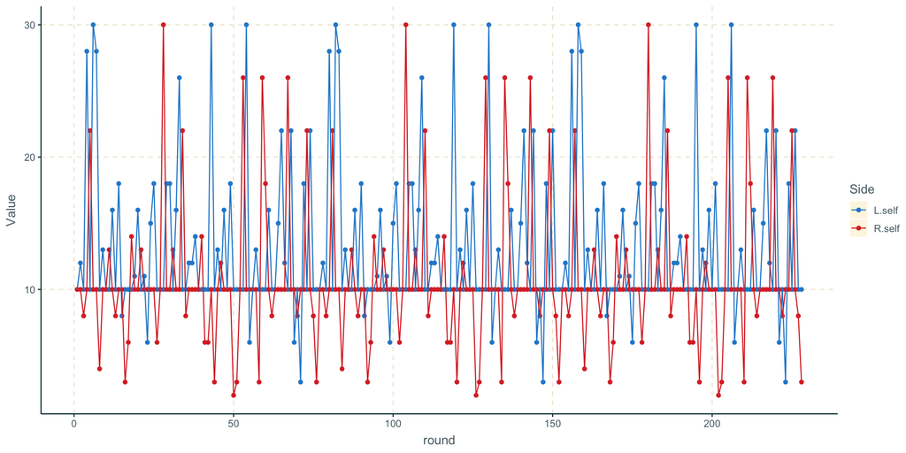

Here is the same thing shown over time in the task. Right is often worse and left is often better (for self payout). At this point we wanted to run some regressions just as a sanity check that each component mattered to subject choice. So we ran logistic mixed effects models, where the fixed effects vars were `Left_Self` `Left_Other` `Right_self` `Right_other` and had a random effect of subject. Each variable significantly contributed to the model, and 95% confidence intervals around the betas did not include 1 for any variable (when converted to log odds ratio)

```
## Generalized linear mixed model fit by maximum likelihood (Laplace
##   Approximation) [glmerMod]
##  Family: binomial  ( logit )
## Formula: side_chosen ~ L.self + L.other + R.self + R.other + (1 | SID)
##    Data: lmData
##
##      AIC      BIC   logLik deviance df.resid
##     2570     2605    -1279     2558     2510
##
## Scaled residuals:
##     Min      1Q  Median      3Q     Max
## -5.3556 -0.5307 -0.3701  0.6809  4.7583
##
## Random effects:
##  Groups Name        Variance Std.Dev.
##  SID    (Intercept) 0.3955   0.6289
## Number of obs: 2516, groups:  SID, 12
##
## Fixed effects:
##              Estimate Std. Error z value Pr(>|z|)
## (Intercept) -1.816090   0.311012  -5.839 5.24e-09 ***
## L.self      -0.080413   0.009849  -8.165 3.23e-16 ***
## L.other      0.099333   0.009127  10.883  < 2e-16 ***
## R.self       0.136104   0.009927  13.711  < 2e-16 ***
## R.other     -0.046601   0.008306  -5.611 2.01e-08 ***
## ---
## Signif. codes:  0 '***' 0.001 '**' 0.01 '*' 0.05 '.' 0.1 ' ' 1
##
## Correlation of Fixed Effects:
##         (Intr) L.self L.othr R.self
## L.self  -0.481
## L.other -0.416  0.016
## R.self  -0.451  0.094  0.089
## R.other -0.448  0.167  0.099  0.089
```

```
##                   Est         LL        UL
## (Intercept) 0.1626605 0.08841855 0.2992408
## L.self      0.9227347 0.90509290 0.9407204
## L.other     1.1044340 1.08485262 1.1243689
## R.self      1.1458012 1.12372295 1.1683133
## R.other     0.9544682 0.93905617 0.9701332
```

Finally, I looked at the left side bias only for trials that were actually counterbalanced. These are the `-12:0` and `12:0`, `-16:0` and `16:0`, `-20:0` and `20:0`, and `-4:1` and `4:1`. If subjects are really paying attention and are not just absentmindedly pressing the left option, we should see that the probability of pressing left on the `-12:0` and `12:0` option should sum to 1. And we see that fore the majority of subjects.

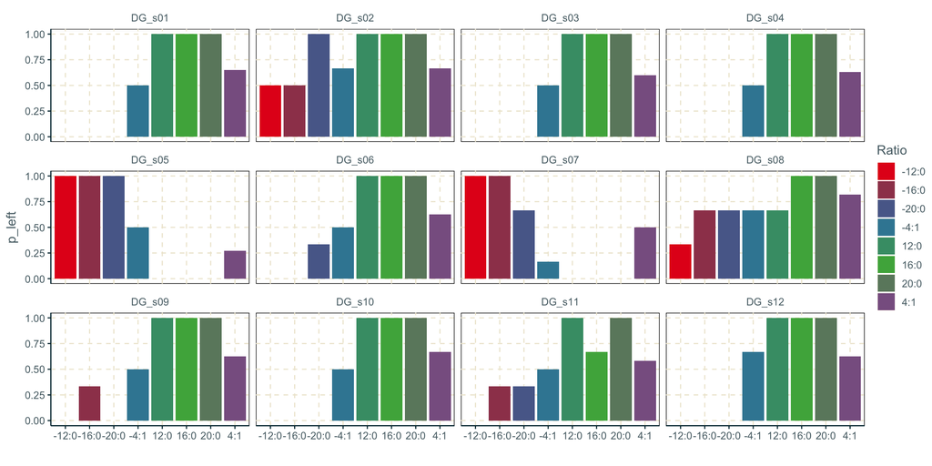

Subject `DG_s02` is more worrying to me, because 100% of the time they selected left when the ratios were `12:0`, `16:0`, `20:0` , but 50-100% of the time they *also selected left* when the ratios were `-12:0`, `-16:0`, `-20:0`. For this subject, it seems harder to say they were encoding the actual values of the options rather than just encoding left is better.

Looking forward to hearing your thoughts on this!